# Travel With US

### Objective

To predict which customer is more likely to purchase the newly introduced travel package "Wellness Tourism Package"

#### Customer details:

- CustomerID: Unique customer ID
- ProdTaken: Whether the customer has purchased a package or not (0: No, 1: Yes)
- Age: Age of customer
- TypeofContact: How customer was contacted (Company Invited or Self Inquiry)
- CityTier: City tier depends on the development of a city, population, facilities, and living standards. The categories are ordered i.e. Tier 1 > Tier 2 > Tier 3
- Occupation: Occupation of customer
- Gender: Gender of customer
- NumberOfPersonVisiting: Total number of persons planning to take the trip with the customer
- PreferredPropertyStar: Preferred hotel property rating by customer
- MaritalStatus: Marital status of customer
- NumberOfTrips: Average number of trips in a year by customer
- Passport: The customer has a passport or not (0: No, 1: Yes)
- OwnCar: Whether the customers own a car or not (0: No, 1: Yes)
- NumberOfChildrenVisiting: Total number of children with age less than 5 planning to take the trip with the customer
- Designation: Designation of the customer in the current organization
- MonthlyIncome: Gross monthly income of the customer

#### Customer interaction data:

- PitchSatisfactionScore: Sales pitch satisfaction score
- ProductPitched: Product pitched by the salesperson
- NumberOfFollowups: Total number of follow-ups has been done by the salesperson after the sales pitch
- DurationOfPitch: Duration of the pitch by a salesperson to the customer

```python
# Import Libraries
import pandas as pd
import numpy as np
from sklearn import metrics
import matplotlib.pyplot as plt
%matplotlib inline
from matplotlib.pyplot import figure
import warnings
warnings.filterwarnings('ignore')
import seaborn as sns
from sklearn.model_selection import train_test_split
from sklearn.model_selection import GridSearchCV
from sklearn import metrics
from sklearn.ensemble import BaggingClassifier,RandomForestClassifier, GradientBoostingClassifier, AdaBoostClassifier, StackingClassifier
from sklearn.tree import DecisionTreeClassifier
```

```python
# Read the Dataset
tourismData = pd.read_excel("Tourism.xlsx", sheet_name='Tourism')
tourismData.head(10)
```

|  | CustomerID | ProdTaken | Age | TypeofContact | CityTier | DurationOfPitch | Occupation | Gender | NumberOfPersonVisiting | NumberOfFollowups | ProductPitched | PreferredPropertyStar | MaritalStatus | NumberOfTrips | Passport | PitchSatisfactionScore | OwnCar | NumberOfChildrenVisiting | Designation | MonthlyIncome |
| --- | --- | --- | --- | --- | --- | --- | --- | --- | --- | --- | --- | --- | --- | --- | --- | --- | --- | --- | --- | --- |
| 0 | 200000 | 1 | 41.0 | Self Enquiry | 3 | 6.0 | Salaried | Female | 3 | 3.0 | Deluxe | 3.0 | Single | 1.0 | 1 | 2 | 1 | 0.0 | Manager | 20993.0 |
| 1 | 200001 | 0 | 49.0 | Company Invited | 1 | 14.0 | Salaried | Male | 3 | 4.0 | Deluxe | 4.0 | Divorced | 2.0 | 0 | 3 | 1 | 2.0 | Manager | 20130.0 |
| 2 | 200002 | 1 | 37.0 | Self Enquiry | 1 | 8.0 | Free Lancer | Male | 3 | 4.0 | Basic | 3.0 | Single | 7.0 | 1 | 3 | 0 | 0.0 | Executive | 17090.0 |
| 3 | 200003 | 0 | 33.0 | Company Invited | 1 | 9.0 | Salaried | Female | 2 | 3.0 | Basic | 3.0 | Divorced | 2.0 | 1 | 5 | 1 | 1.0 | Executive | 17909.0 |
| 4 | 200004 | 0 | NaN | Self Enquiry | 1 | 8.0 | Small Business | Male | 2 | 3.0 | Basic | 4.0 | Divorced | 1.0 | 0 | 5 | 1 | 0.0 | Executive | 18468.0 |
| 5 | 200005 | 0 | 32.0 | Company Invited | 1 | 8.0 | Salaried | Male | 3 | 3.0 | Basic | 3.0 | Single | 1.0 | 0 | 5 | 1 | 1.0 | Executive | 18068.0 |
| 6 | 200006 | 0 | 59.0 | Self Enquiry | 1 | 9.0 | Small Business | Female | 2 | 2.0 | Basic | 5.0 | Divorced | 5.0 | 1 | 2 | 1 | 1.0 | Executive | 17670.0 |
| 7 | 200007 | 0 | 30.0 | Self Enquiry | 1 | 30.0 | Salaried | Male | 3 | 3.0 | Basic | 3.0 | Married | 2.0 | 0 | 2 | 0 | 1.0 | Executive | 17693.0 |
| 8 | 200008 | 0 | 38.0 | Company Invited | 1 | 29.0 | Salaried | Male | 2 | 4.0 | Standard | 3.0 | Unmarried | 1.0 | 0 | 3 | 0 | 0.0 | Senior Manager | 24526.0 |
| 9 | 200009 | 0 | 36.0 | Self Enquiry | 1 | 33.0 | Small Business | Male | 3 | 3.0 | Deluxe | 3.0 | Divorced | 7.0 | 0 | 3 | 1 | 0.0 | Manager | 20237.0 |

```python
# tourismData shape
print(f'There are {tourismData.shape[0]} rows and {tourismData.shape[1]} columns.')
```

[output not shown]

```python
tourismData.info()
```

```
<class 'pandas.core.frame.DataFrame'>
RangeIndex: 4888 entries, 0 to 4887
Data columns (total 20 columns):
 #   Column                    Non-Null Count  Dtype
---  ------                    --------------  -----
 0   CustomerID                4888 non-null   int64
 1   ProdTaken                 4888 non-null   int64
 2   Age                       4662 non-null   float64
 3   TypeofContact             4863 non-null   object
 4   CityTier                  4888 non-null   int64
 5   DurationOfPitch           4637 non-null   float64
 6   Occupation                4888 non-null   object
 7   Gender                    4888 non-null   object
 8   NumberOfPersonVisiting    4888 non-null   int64
 9   NumberOfFollowups         4843 non-null   float64
 10  ProductPitched            4888 non-null   object
 11  PreferredPropertyStar     4862 non-null   float64
 12  MaritalStatus             4888 non-null   object
 13  NumberOfTrips             4748 non-null   float64
 14  Passport                  4888 non-null   int64
 15  PitchSatisfactionScore    4888 non-null   int64
 16  OwnCar                    4888 non-null   int64
 17  NumberOfChildrenVisiting  4822 non-null   float64
 18  Designation               4888 non-null   object
 19  MonthlyIncome             4655 non-null   float64
dtypes: float64(7), int64(7), object(6)
memory usage: 763.9+ KB
```

```python
tourismData.isnull().values.any() # If there are any null values in data set
```

```
True
```

### Observations:

1. There are 20 features, out of which few have missing values. We will try to impute these.
2. Dataset has a mix of int, float and string (object) values.
3. CustomerID looks like a unique ID column for the customers. We will further analyze this and if this does not seem to add any value, we will drop it from the dataset.

```python
#Let's find out the number of missing values in each column.
tourismData.isna().sum()
```

```
CustomerID                    0
ProdTaken                     0
Age                         226
TypeofContact                25
CityTier                      0
DurationOfPitch             251
Occupation                    0
Gender                        0
NumberOfPersonVisiting        0
NumberOfFollowups            45
ProductPitched                0
PreferredPropertyStar        26
MaritalStatus                 0
NumberOfTrips               140
Passport                      0
PitchSatisfactionScore        0
OwnCar                        0
NumberOfChildrenVisiting     66
Designation                   0
MonthlyIncome               233
dtype: int64
```

### Observations:

Missing values per column:

- Age = 226
- TypeofContact = 25
- DurationOfPitch = 251
- NumberOfFollowups = 45
- PreferredPropertyStar = 26
- NumberOfTrips = 140
- NumberOfChildrenVisiting= 66
- MonthlyIncome = 233

Before imputing the values for each column, let's see the distribution of data in each of these features.

```python
tourismData.describe()
```

|  | CustomerID | ProdTaken | Age | CityTier | DurationOfPitch | NumberOfPersonVisiting | NumberOfFollowups | PreferredPropertyStar | NumberOfTrips | Passport | PitchSatisfactionScore | OwnCar | NumberOfChildrenVisiting | MonthlyIncome |
| --- | --- | --- | --- | --- | --- | --- | --- | --- | --- | --- | --- | --- | --- | --- |
| count | 4888.000000 | 4888.000000 | 4662.000000 | 4888.000000 | 4637.000000 | 4888.000000 | 4843.000000 | 4862.000000 | 4748.000000 | 4888.000000 | 4888.000000 | 4888.000000 | 4822.000000 | 4655.000000 |
| mean | 202443.500000 | 0.188216 | 37.622265 | 1.654255 | 15.490835 | 2.905074 | 3.708445 | 3.581037 | 3.236521 | 0.290917 | 3.078151 | 0.620295 | 1.187267 | 23619.853491 |
| std | 1411.188388 | 0.390925 | 9.316387 | 0.916583 | 8.519643 | 0.724891 | 1.002509 | 0.798009 | 1.849019 | 0.454232 | 1.365792 | 0.485363 | 0.857861 | 5380.698361 |
| min | 200000.000000 | 0.000000 | 18.000000 | 1.000000 | 5.000000 | 1.000000 | 1.000000 | 3.000000 | 1.000000 | 0.000000 | 1.000000 | 0.000000 | 0.000000 | 1000.000000 |
| 25% | 201221.750000 | 0.000000 | 31.000000 | 1.000000 | 9.000000 | 2.000000 | 3.000000 | 3.000000 | 2.000000 | 0.000000 | 2.000000 | 0.000000 | 1.000000 | 20346.000000 |
| 50% | 202443.500000 | 0.000000 | 36.000000 | 1.000000 | 13.000000 | 3.000000 | 4.000000 | 3.000000 | 3.000000 | 0.000000 | 3.000000 | 1.000000 | 1.000000 | 22347.000000 |
| 75% | 203665.250000 | 0.000000 | 44.000000 | 3.000000 | 20.000000 | 3.000000 | 4.000000 | 4.000000 | 4.000000 | 1.000000 | 4.000000 | 1.000000 | 2.000000 | 25571.000000 |
| max | 204887.000000 | 1.000000 | 61.000000 | 3.000000 | 127.000000 | 5.000000 | 6.000000 | 5.000000 | 22.000000 | 1.000000 | 5.000000 | 1.000000 | 3.000000 | 98678.000000 |

- Age- slightly right skewed, we will replace missing values with median.
- DurationOfPitch- slightly right skewed, we will replace missing values with median.
- NumberOfFollowups- normally distributed, we will replace missing values with median.
- PreferredPropertyStar- normally distributed, we will replace missing values with median.
- NumberOfTrips- normally distributed, we will replace missing values with median.
- NumberOfChildrenVisiting- normally distributed, we will replace missing values with median.
- MonthlyIncome- slightly right skewed, we will replace missing values with median.
- CityTier- we will replace missing values with median.
- TypeofContact- since this is a string value, it not possible to find median or mean, rather than imputing with most frequent values (that might introduce bias), we will drop the rows with missing values.

```python
#Imputing missing values for each feature with median.
tourismData['Age'] = tourismData['Age'].transform(lambda x: x.fillna(x.median()))
tourismData['DurationOfPitch'] = tourismData['DurationOfPitch'].transform(lambda x: x.fillna(x.median()))
tourismData['NumberOfFollowups'] = tourismData['NumberOfFollowups'].transform(lambda x: x.fillna(x.median()))
tourismData['PreferredPropertyStar'] = tourismData['PreferredPropertyStar'].transform(lambda x: x.fillna(x.median()))
tourismData['NumberOfTrips'] = tourismData['NumberOfTrips'].transform(lambda x: x.fillna(x.median()))
tourismData['NumberOfChildrenVisiting'] = tourismData['NumberOfChildrenVisiting'].transform(lambda x: x.fillna(x.median()))
tourismData['MonthlyIncome'] = tourismData['MonthlyIncome'].transform(lambda x: x.fillna(x.median()))
tourismData['CityTier'] = tourismData['CityTier'].transform(lambda x: x.fillna(x.median()))
```

```python
#lets find the index of missing values and then we will drop the rows for those indices.
tourismData['TypeofContact'].value_counts()
```

```
Self Enquiry       3444
Company Invited    1419
Name: TypeofContact, dtype: int64
```

```python
index_names = tourismData[ (tourismData['TypeofContact'].isna()) ].index
```

```python
print(f'There are {len(index_names)} rows with missing values of TypeofContact.')
```

```
There are 25 rows with missing values of TypeofContact.
```

```python
# Dropping the rows with index in "index_names" list-25 rows with missing values of TypeofContact.
tourismData.drop(index_names, inplace = True)
```

```python
tourismData.isna().sum()
```

```
CustomerID                  0
ProdTaken                   0
Age                         0
TypeofContact               0
CityTier                    0
DurationOfPitch             0
Occupation                  0
Gender                      0
NumberOfPersonVisiting      0
NumberOfFollowups           0
ProductPitched              0
PreferredPropertyStar       0
MaritalStatus               0
NumberOfTrips               0
Passport                    0
PitchSatisfactionScore      0
OwnCar                      0
NumberOfChildrenVisiting    0
Designation                 0
MonthlyIncome               0
dtype: int64
```

### Observations:

1. Now there are no more missing values in any feature.

```python
#Listing unique values in each feature of the dataset "tourismData"
for i in tourismData.columns:
    print('Unique values in',i, 'are :')
    print(tourismData[i].value_counts())
    print('*'*50)
```

```
Unique values in CustomerID are :
204800    1
200167    1
202212    1
200163    1
204257    1
         ..
203522    1
201471    1
203518    1
201467    1
200702    1
Name: CustomerID, Length: 4863, dtype: int64
Unique values in ProdTaken are :
0    3946
1     917
Name: ProdTaken, dtype: int64
Unique values in Age are :
36.0    456
35.0    237
34.0    208
31.0    201
30.0    199
32.0    195
33.0    188
37.0    185
29.0    176
38.0    176
41.0    154
39.0    150
40.0    146
28.0    145
42.0    142
27.0    136
43.0    130
46.0    121
45.0    115
44.0    105
26.0    102
51.0     90
```

[output cut: 152 more lines]

```
VP                 230
Name: Designation, dtype: int64
Unique values in MonthlyIncome are :
22347.0    210
20855.0      7
21020.0      7
17342.0      7
21288.0      7
          ...
25194.0      1
21628.0      1
17863.0      1
25477.0      1
18537.0      1
Name: MonthlyIncome, Length: 2475, dtype: int64
```

### Observations:

1. ProdTaken (dependent var) has 2 unique (boolean) values. 0=Not bought Product, 1= Bought the Product.
2. TypeOfContact has 2 unique values- Self Enquiry and Company Invited.
3. Occupation has 4 unique values- Salaried, Small Business, Large Business and Free Lancer.
4. NumberOfPersonVisisting have 5 unique values- 1, 2 , 3, 4 and 5
5. NumberOfFollowups has 6 unique values- 1, 2, 3, 4, 5 and 6.
6. ProductPitched has 5 unique values- Basic, Deluxe, Standard, Super Delux, and King.
7. PreferredPorpertyStar has 3 unique values- 3, 4 and 5.
8. MaritalStatus has 4 uniq values- Married, Divorced, Single and Unmarried.
9. NumberOfTrips has 12 unique values - 1 to 8 and 19,20,21,22. There are only 4 observations (customers) who take 19,20,21 and 22 trips per year, these clearly are outliers.
10. Passport has 2 unique (boolean) values, 0=Does not have Passport, 1= Has Passport.
11. PitchSatisfactionScore has 5 unique values. This looks like a range for the score. The most frequent occuring score is 3.
12. HasOwnCar has 2 unique (boolean) values, 0=Does not have car, 1=Has own car.
13. NumberOfChildrenVisiting has 4 unique values- 0, 1, 2 and 3. Most of the people travel with 1 child and least with 3 children.
14. Designation has 5 unique values- Executive, Manager, Senior Manager, AVP and VP.
15. CityTier has 3 unique values, representing Tier1, Tier2 and Tier3 cities. City tier depends on the development of a city, population, facilities, and living standards. The categories are ordered i.e. Tier 1 > Tier 2 > Tier 3
16. Features like MonthlyIncome, DurationOfPitch, Age and CustomerID have a lot of unique values and represent the continous variables.
17. Unique values in Gender are - Male, Female and Fe Male.'Fe Male' is clearly a typing error, so we will correct this.
18. We will drop CustomerID as this is a feature with unique ID of the customer and won't add any value to the modelling process.

```python
# Replace Fe Male with Female in the Gender feature
tourismData['Gender'] = tourismData['Gender'].replace({'Fe Male':'Female'})

#drop CustomerID
tourismData.drop('CustomerID',inplace=True, axis=1)
```

```python
#Let's look at the dataset again after the datatype conversion
tourismData.info()
```

```
<class 'pandas.core.frame.DataFrame'>
Int64Index: 4863 entries, 0 to 4887
Data columns (total 19 columns):
 #   Column                    Non-Null Count  Dtype
---  ------                    --------------  -----
 0   ProdTaken                 4863 non-null   int64
 1   Age                       4863 non-null   float64
 2   TypeofContact             4863 non-null   object
 3   CityTier                  4863 non-null   int64
 4   DurationOfPitch           4863 non-null   float64
 5   Occupation                4863 non-null   object
 6   Gender                    4863 non-null   object
 7   NumberOfPersonVisiting    4863 non-null   int64
 8   NumberOfFollowups         4863 non-null   float64
 9   ProductPitched            4863 non-null   object
 10  PreferredPropertyStar     4863 non-null   float64
 11  MaritalStatus             4863 non-null   object
 12  NumberOfTrips             4863 non-null   float64
 13  Passport                  4863 non-null   int64
 14  PitchSatisfactionScore    4863 non-null   int64
 15  OwnCar                    4863 non-null   int64
 16  NumberOfChildrenVisiting  4863 non-null   float64
 17  Designation               4863 non-null   object
 18  MonthlyIncome             4863 non-null   float64
dtypes: float64(7), int64(6), object(6)
memory usage: 759.8+ KB
```

### Observations:

1. We have treated all the missing values and dropped the features that did not add any value.
2. There are no null or missing values in the dataset anymore.

# EDA- Univariate

```python
# Function to create boxplot and histogram for any input numerical variable.
# This function takes the numerical column as the input and returns the boxplots and histograms for the variable.
def histogram_boxplot(feature, figsize=(15,10), bins = None):
    """ Boxplot and histogram combined
    feature: 1-d feature array
    figsize: size of fig (default (9,8))
    bins: number of bins (default None / auto)
    """
    f2, (ax_box2, ax_hist2) = plt.subplots(nrows = 2, # Number of rows of the subplot grid= 2
                                           sharex = True, # x-axis will be shared among all subplots
                                           gridspec_kw = {"height_ratios": (.25, .75)},
                                           figsize = figsize
                                           ) # creating the 2 subplots
    sns.boxplot(feature, ax=ax_box2, showmeans=True, color='violet') # boxplot will be created and a star will indicate the mean value of the column
    sns.distplot(feature, kde=F, ax=ax_hist2, bins=bins,palette="winter") if bins else sns.distplot(feature, kde=False, ax=ax_hist2) # For histogram
    ax_hist2.axvline(np.mean(feature), color='green', linestyle='--') # Add mean to the histogram
    ax_hist2.axvline(np.median(feature), color='black', linestyle='-') # Add median to the histogram
```

### Analysis for the following continous features:

- Age
- DurationOfPitch
- MonthlyIncome

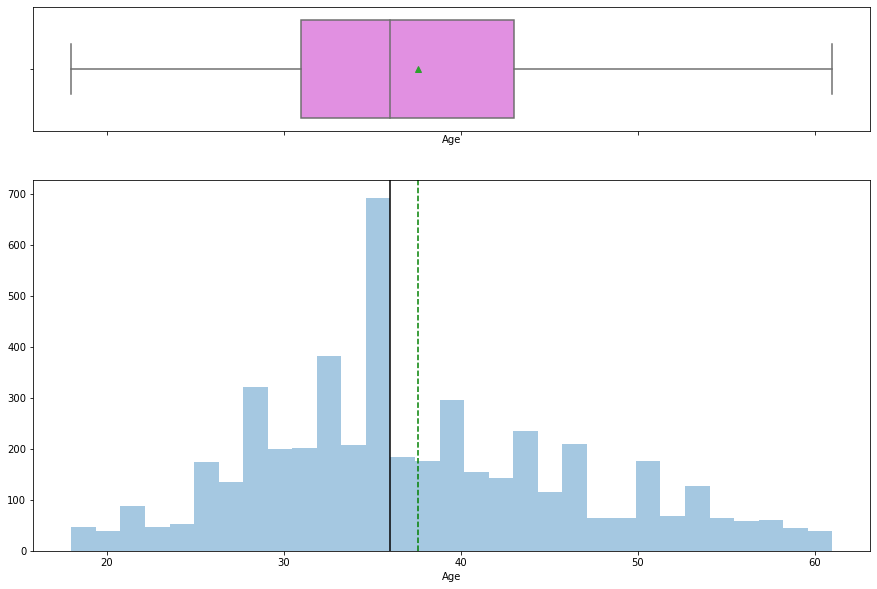

```python
histogram_boxplot(tourismData['Age'])
```

### Observations:

1. Age feature is very slightly right skewed with no outliers.
2. Median age of customers is 36 years, that means that the people mostly in their mid 30s are more likely to buy a travel package.
3. Age range of customers vary from 18-61 years.

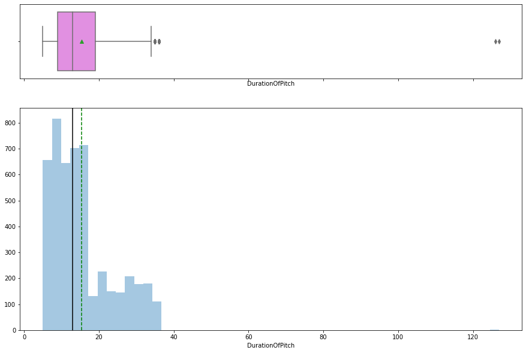

```python
histogram_boxplot(tourismData['DurationOfPitch'])
```

### Observations:

1. DurationOfPitch is very slightly right skewed with very few outliers. Since we will be using Decision Tree classifiers, we will not treat the outliers because Decision trees divide items by lines, so it does not matter how far is a point from lines.
2. The median value of pitch is 13 mins (since the unit of "DurationOfPitch" feature is not given, we are assuming that its in minutes), that means that mostly a sales pitch lasts for 13 mins.
3. We also see outliers and that is evident from the dataset where the max pitch duration is 127 mins, which is way above mean (15.4 mins) and median (13 mins), this shows that few customers might have additional inquiries during hte sales pitch.

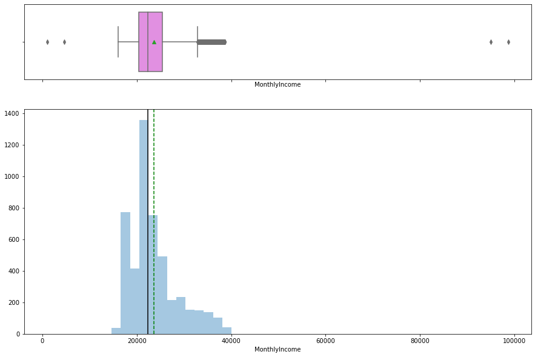

```python
histogram_boxplot(tourismData['MonthlyIncome'])
```

### Observations:

1. MonthlyIncome is very slightly right skewed with some outliers. Since we will be using Decision Tree classifiers, we will not treat the outliers because Decision trees divide items by lines, so it does not matter how far is a point from lines.
2. Median gross monthly income of the customers is 22,347, meaning customers who buy the travel package, most of them have salary around 22,347 (unit not known).
3. The mean monthly gross salary is 23,619, but the minimum salary is 1000 in the dataset and max is 98,678. This clearly shows that there are some outliers on both sides (below min whisker and above max whisker) which is also evident from the boxplot.

## Categorical and Boolean features

```python
# Function to create barplots that indicate percentage for each category.

def perc_on_bar(plot, feature):
    '''
    plot
    feature: categorical feature
    the function won't work if a column is passed in hue parameter
    '''

    total = len(feature) # length of the column
    for p in ax.patches:
        percentage = '{:.1f}%'.format(100 * p.get_height()/total) # percentage of each class of the category
        x = p.get_x() + p.get_width() / 2 - 0.05 # width of the plot
        y = p.get_y() + p.get_height()           # hieght of the plot
        ax.annotate(percentage, (x, y), size = 12) # annotate the percantage
    figure(figsize=(20,10), dpi=80)
    plt.show() # show the plot
```

### Analysis for the following categorical boolean features:

- ProdTaken
- Passport
- OwnCar

```
Count of people by ProdTaken
0    3946
1     917
Name: ProdTaken, dtype: int64
```

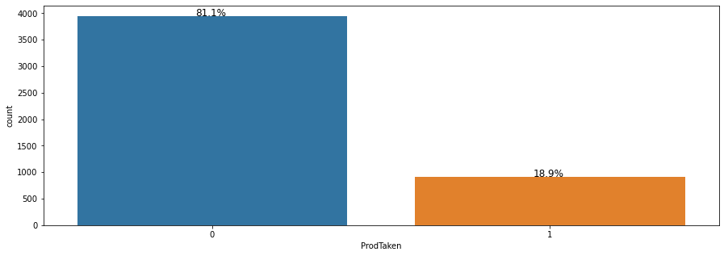

```python
print(f'Count of people by ProdTaken \n{tourismData.ProdTaken.value_counts()}')
plt.figure(figsize=(15,5))
ax = sns.countplot(tourismData["ProdTaken"])
perc_on_bar(ax,tourismData["ProdTaken"])
```

### Observations:

1. 18.9 % people bought the travel package while 81.1% did not buy the package.

```
Count of people with and without Passport
0    3441
1    1422
Name: Passport, dtype: int64
```

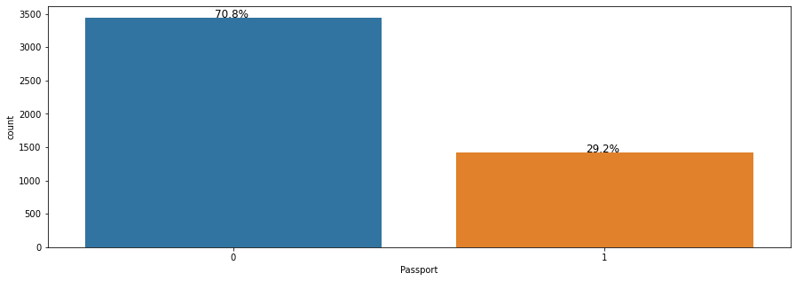

```python
print(f'Count of people with and without Passport \n{tourismData.Passport.value_counts()}')
plt.figure(figsize=(15,5))
ax = sns.countplot(tourismData["Passport"])
perc_on_bar(ax,tourismData["Passport"])
```

### Observations:

1. 70.8 % people do not have the passport and 29.2% people have the passport.
2. Passport is required for International Travel, so the Travel Agency can either target people with no passport for Domestic Travel packages or provide Passport Assistance to the people who are interested in International Travel but do not have passport.

```
Count of people who do and do not own car
1    3018
0    1845
Name: OwnCar, dtype: int64
```

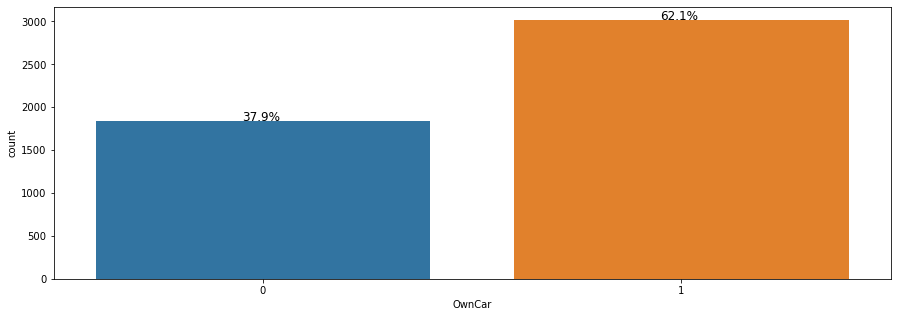

```python
print(f'Count of people who do and do not own car \n{tourismData.OwnCar.value_counts()}')
plt.figure(figsize=(15,5))
ax = sns.countplot(tourismData["OwnCar"])
perc_on_bar(ax,tourismData["OwnCar"])
```

### Observations:

1. 62.1 % people own car but 37.9% people do not own a car.
2. Travel Agency can look at providing chauffeur service to the people who do not own a car or people who do not want to use their personal car for travel purpose, to get them to their destination/pickup place etc for Travel Package.

#### Analysis of the categorical features:

- TypeofContact
- CityTier
- Occupation
- Gender
- NumberOfPersonVisiting
- NumberOfFollowups
- ProductPitched
- PreferredPropertyStar
- MaritalStatus
- NumberOfTrips
- PitchSatisfactionScore
- NumberOfChildrenVisiting
- Designation

```
Count of people by TypeofContact
Self Enquiry       3444
Company Invited    1419
Name: TypeofContact, dtype: int64
```

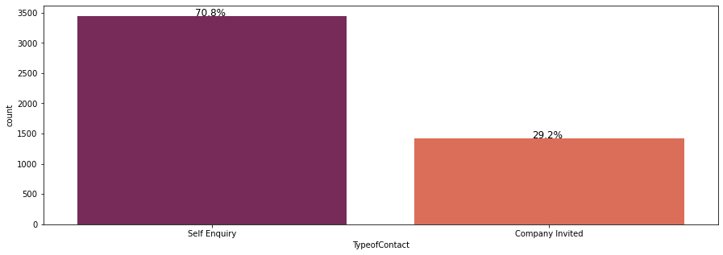

```python
print(f'Count of people by TypeofContact \n{tourismData.TypeofContact.value_counts()}')
plt.figure(figsize=(15,5))
ax = sns.countplot(tourismData["TypeofContact"],palette='rocket')
perc_on_bar(ax,tourismData["TypeofContact"])
```

### Observations:

1. 70.8% people reached out to Travel Agency for inquiry by self and 29.2% people were invited by agency.
2. This shows that Travel Agency has good presence and people are able to reach agency by themselves. It will be good to know what is the mode of contact (phone, email, chat) and which platform most enquiries are coming from (Social Media, Print Ads, Word of mouth etc.), so that Agency can advertise more through that channel and platform.

```
Count of people by CityTier
1    3173
3    1492
2     198
Name: CityTier, dtype: int64
```

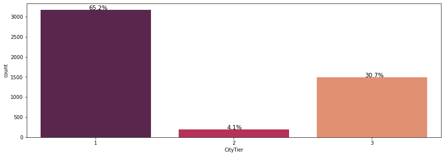

```python
print(f'Count of people by CityTier \n{tourismData.CityTier.value_counts()}')
plt.figure(figsize=(15,5))
ax = sns.countplot(tourismData["CityTier"],palette='rocket')
perc_on_bar(ax,tourismData["CityTier"])
```

### Observations:

1. Out of all the people who got the information for Travel Packge, 65.2% are from Tier1 cities, 30.7% are from Tier3 cities and only 4.1% are from Tier2 cities.
2. We will further explore and try to find the possibilities to engage with more Tier2 city people and have them intereseted in the travel package.

```
Count of people by Occupation
Salaried          2363
Small Business    2064
Large Business     434
Free Lancer          2
Name: Occupation, dtype: int64
```

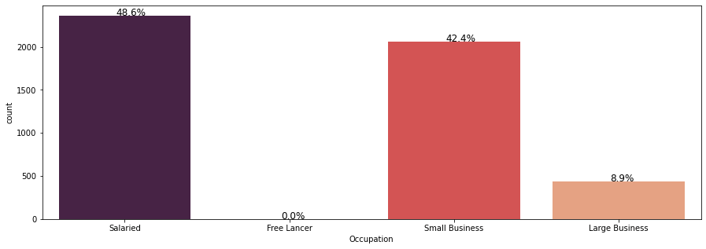

```python
print(f'Count of people by Occupation \n{tourismData.Occupation.value_counts()}')
plt.figure(figsize=(15,5))
ax = sns.countplot(tourismData["Occupation"],palette='rocket')
perc_on_bar(ax,tourismData["Occupation"])
```

### Observations:

1. Out of all the people who got the information for Travel Packge, 48.6% are salaried, 42.4% have small business, 8.9% have large business and only two free lancers.
2. Looks like Travel Agency has a lot of affordable Travel packages targetting salaried and small business folks, they can also increase their range to attarct people with large businesses as well as free lancers.
3. We will explore more on the spending (travel package bought) by Occupation.

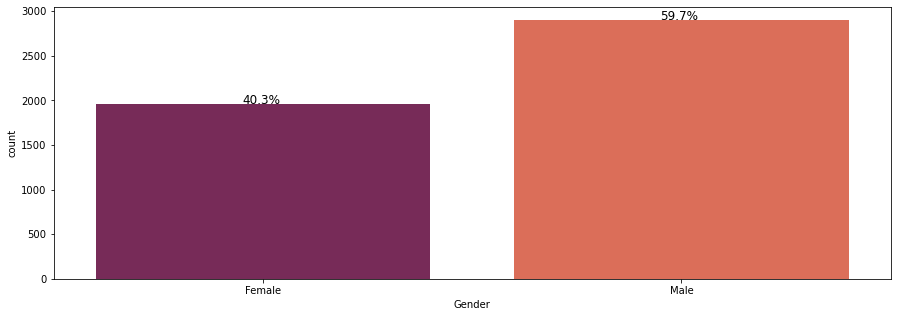

```python
plt.figure(figsize=(15,5))
ax = sns.countplot(tourismData["Gender"],palette='rocket')
perc_on_bar(ax,tourismData["Gender"])
```

### Observations:

1. Out of all the people who got the information for Travel Packge, 40.3% are females and 59.7% are male.
2. This seems to be a good mix, however not equal. We will further explore if there is any scope to have more females interested in the travel packages information.

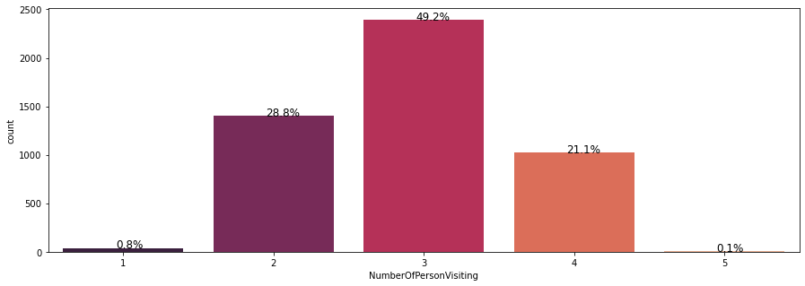

```python
plt.figure(figsize=(15,5))
ax = sns.countplot(tourismData["NumberOfPersonVisiting"],palette='rocket')
perc_on_bar(ax,tourismData["NumberOfPersonVisiting"])
```

### Observations:

1. Out of all the people who got information for the Travel pacakges, 49.2% mentioned that number of people travelling will be 3 people, 28.8% people mentioned that number of people travelling will be 2, 21.1% said that number of people travelling will be 4 and less than 1% people mentioned single travellers or 5 travellers.
2. From this stat, it looks like majority of poeple either travel with their partners or small family or groups of 3 & 4.
3. There are very less single travelers or travelers with large groups, however this is a niche market.
4. Travel company can look at adding lucrative travel packages for small families and groups. Also focus on Travel packages like couple retreat where they focus on an experience.
5. Single travelers though are less in number, still there might be some opportunity there. Travel company can look at creating Travel packages for Single travelers who would either like to travel by themselves or join a group travel.
6. Traveling in a large group/ family might get difficult, the travel company can create niche packages for such customers where they focus on logistics based on different age people traveling in a group.

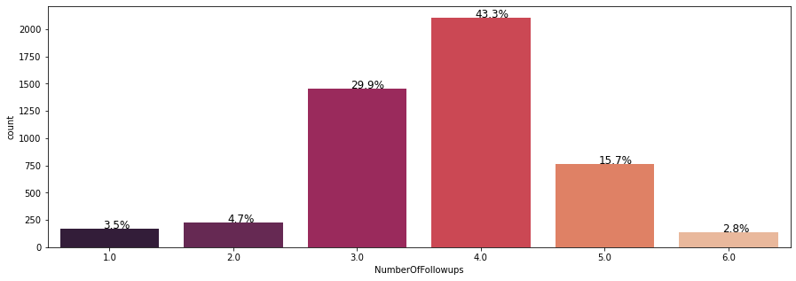

```python
plt.figure(figsize=(15,5))
ax = sns.countplot(tourismData["NumberOfFollowups"],palette='rocket')
perc_on_bar(ax,tourismData["NumberOfFollowups"])
```

### Observations:

1. Out of all the people who got information on the Travel Packages, with 43.3 % people, the salesperson has to follow up 4 times, with 29.9 % people, the salesperson has to follow up 3 times, with 15.7 % people, the salesperson has to follow up 5 times, with 4.7 % people, the salesperson has to follow up 2 times, with 3.5 % people, the salesperson has to follow up 1 time and with 2.8% people sales person had to follow up 6 times.
2. Further we will explore after how many follow ups the sales person was able to convert the sale.
3. It will be good to know what was the reason of follow ups, that would give an insight on what can be improved with that interaction, few things can be improved in sales pitch, that would reduce the number of follow ups and help in converting the sale faster.

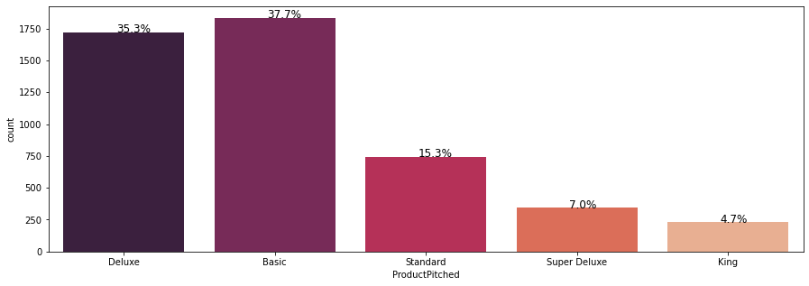

```python
plt.figure(figsize=(15,5))
ax = sns.countplot(tourismData["ProductPitched"],palette='rocket')
perc_on_bar(ax,tourismData["ProductPitched"])
```

### Observations:

1. Out of all the people who got information on the Travel Packages, 37.7% were pitched Basic Package, 35.3% were pitched Deluxe package, 15.3% were pitched Standard package, 7% were pitched Super Deluxe package and 4.7% were pitched King Package.
2. Further we will explore, which package was most popular in the sales that got converted, also what is the customer profile for each package.

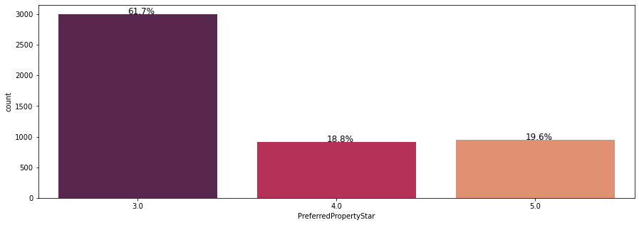

```python
plt.figure(figsize=(15,5))
ax = sns.countplot(tourismData["PreferredPropertyStar"],palette='rocket')
perc_on_bar(ax,tourismData["PreferredPropertyStar"])
```

### Observations:

1. Out of all the people who got information on the Travel Packages, 61.7 % preferred 3 star properties, 19.6% preferred 5 star properties and 18.8% preferred 4 star properties.

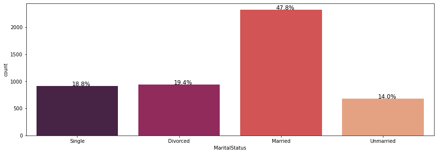

```python
plt.figure(figsize=(15,5))
ax = sns.countplot(tourismData["MaritalStatus"],palette='rocket')
perc_on_bar(ax,tourismData["MaritalStatus"])
```

### Observations:

1. Out of all the people who got information on the Travel Packages, 47.8% were married, 19.4 % were divorced, 18.8% were Single and 14% were unmarried.
2. From this stat, it looks like the Travel packages presented by travel company are most popular among married people.
3. Divorced and Single people are almost at same percentage with Unmarried people at slightly low percentage.

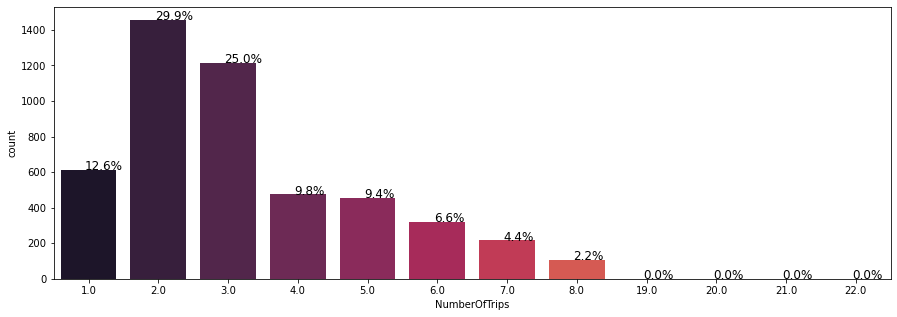

```python
plt.figure(figsize=(15,5))
ax = sns.countplot(tourismData["NumberOfTrips"],palette='rocket')
perc_on_bar(ax,tourismData["NumberOfTrips"])
```

### Observations:

1. Out of all the people who got information on the Travel Packages, on an average, 29.9% of those take 2 trips per year, 25% take 3 trips a year, 12.6% take 1 trip per year, 9.8% take 4 trips per year, 9.4% take 5 trips per year, 6.6% take 6 trips per year, 4.4% take 7 trips per year, 2.2% take 8 trips per year and only 1 person takes 19 trips per year, 1 person takes 20 trips per year, 1 person takes 21 trips per yar and 1 person takes 22 trips per year.
2. From this stat, it looks like the most of the people take on an average 2 or 3 trips per year.

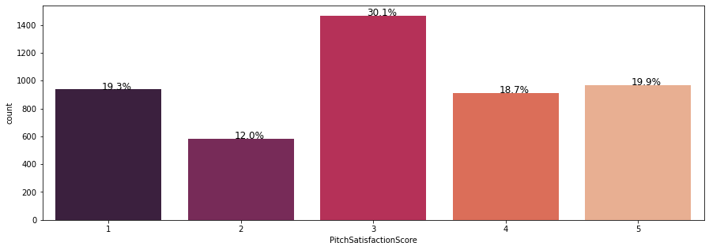

```python
plt.figure(figsize=(15,5))
ax = sns.countplot(tourismData["PitchSatisfactionScore"],palette='rocket')
perc_on_bar(ax,tourismData["PitchSatisfactionScore"])
```

### Observations:

1. Out of all the people who got information on the Travel Packages, 30.1% gave a score of 3 for the Product pitch that they received, 19.9% gave a score of 5 for the Product pitch that they received, 19.3% gave a score of 1 for the Product pitch that they received, 18.7% gave a score of 4 for the Product pitch that they received and 12% gave a score of 2 for the Product pitch that they received.
2. We will further explore how this score is related to ProdTaken feature.

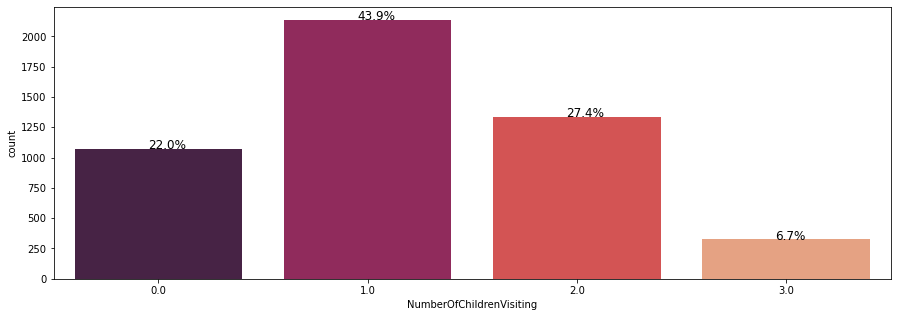

```python
plt.figure(figsize=(15,5))
ax = sns.countplot(tourismData["NumberOfChildrenVisiting"],palette='rocket')
perc_on_bar(ax,tourismData["NumberOfChildrenVisiting"])
```

### Observations:

1. Out of all the people who got information on the Travel Packages,22% are not planning to bring children under the age of 5 with them, 43.9% are planning to bring 1 kid under the age of 5, 27.4% are planning to bring 2 kids under the age of 5 and 6.7% are planning to bring 3 kids under the age of 5.
2. Based on this stat, it looks like most of the travelers have atleast 1 kid under the age of 5.
3. Travel agency can use this data to create "kid friendly" travel packages considering the needs of parents traveling with young children.

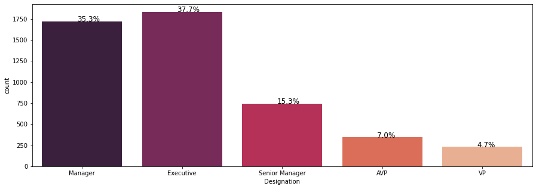

```python
plt.figure(figsize=(15,5))
ax = sns.countplot(tourismData["Designation"],palette='rocket')
perc_on_bar(ax,tourismData["Designation"])
```

### Observations:

1. Out of all the people who got information on the Travel Packages, 35.3% are managers, 37.7% are Executives, 15.3% are Senior Managers, 7% are AVP and 4.7% are VPs in their organization.

# Bivariate

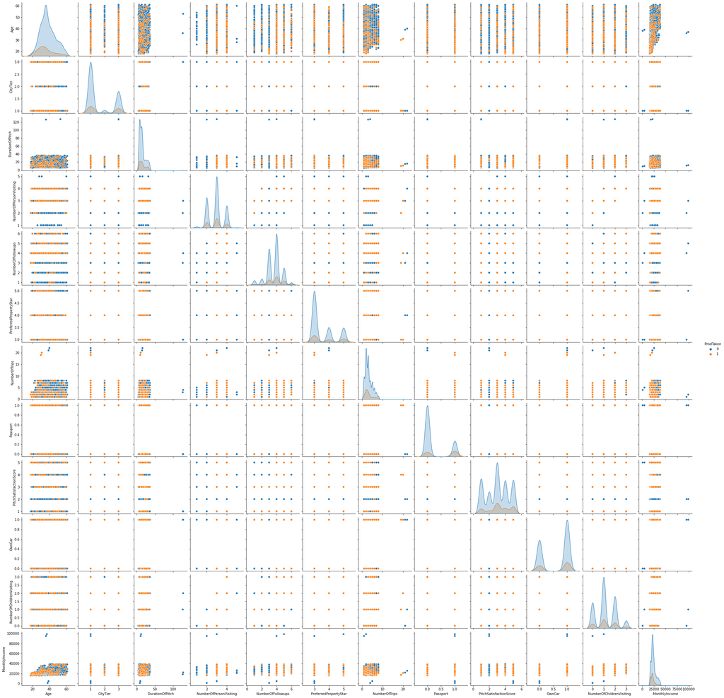

```python
sns.pairplot(tourismData,hue='ProdTaken')
plt.show()
```

### Observations:

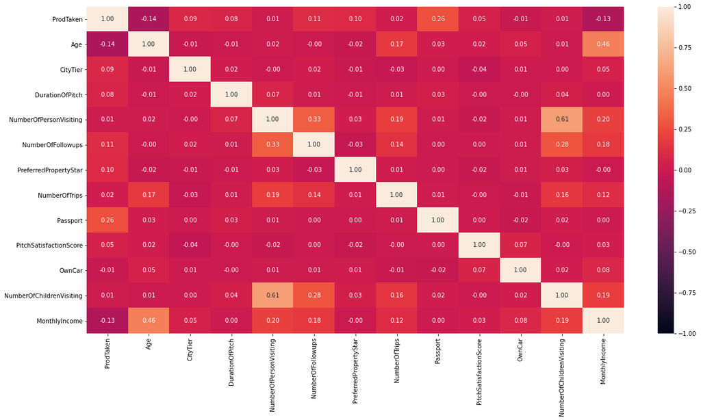

```python
plt.figure(figsize=(20,10))
sns.heatmap(tourismData.corr(),annot=True,vmin=-1,vmax=1,fmt='.2f')
plt.show()
```

### Observations:

1. NumberOfChildrenTraveling and NumberOfPersonsVisiting are positively correlated, which makes sense as number of children accompaning their parents are also counted with NumberOfPersonsVisiting.
2. Age and MonthlyIncome are also slightly postively correlated.

```
ProdTaken vs Age
```

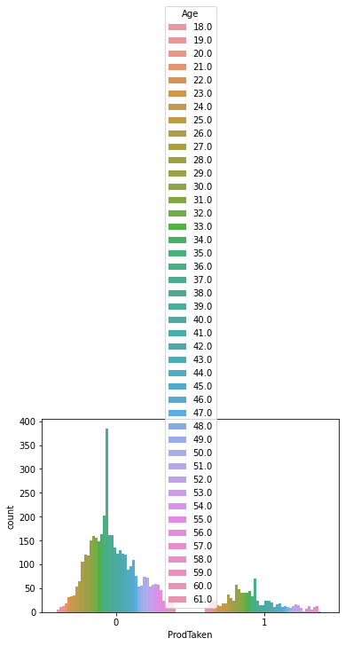

```python
# ProdTaken vs Age
print('ProdTaken vs Age')
#print('  ')
#print(tourismData.groupby('Age')['ProdTaken'].value_counts(ascending=False))
sns.countplot(x=tourismData['ProdTaken'],hue=tourismData['Age']);
```

### Observations:

1. Most of the people who bought the product were from age 29-35 years.
2. Coincidently, that is also the age range for most of the customers of Travel Agency.

```
ProdTaken vs TypeofContact

TypeofContact    ProdTaken
Company Invited  0            1109
                 1             310
Self Enquiry     0            2837
                 1             607
Name: ProdTaken, dtype: int64
```

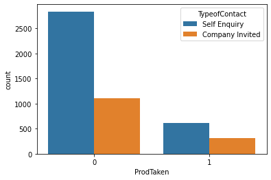

```python
# ProdTaken vs TypeofContact
print('ProdTaken vs TypeofContact')
print('  ')
print(tourismData.groupby('TypeofContact')['ProdTaken'].value_counts(ascending=False))
sns.countplot(x=tourismData['ProdTaken'],hue=tourismData['TypeofContact']);
```

### Observations:

1. Most of the people who bought the product came through Self Enquiry.
2. From this stat it looks the most of the customers who either buy or not buy the product come in through Self Enquiry.
3. The Travel Agency can try to increase its outreach to reach out to more customers to promote their Travel Packages.

```
ProdTaken vs CityTier

Count of ProdTaken by CityTier

CityTier  ProdTaken
1         0            2655
          1             518
2         0             152
          1              46
3         0            1139
          1             353
Name: ProdTaken, dtype: int64

Percentage of ProdTaken by CityTier

CityTier  ProdTaken
1         0            54.595928
          1            10.651861
2         0             3.125643
          1             0.945918
3         0            23.421756
          1             7.258894
Name: ProdTaken, dtype: float64
```

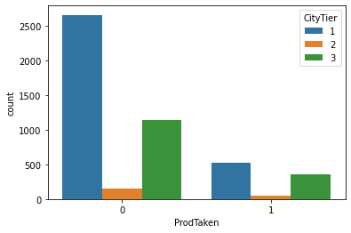

```python
# ProdTaken vs CityTier
print('ProdTaken vs CityTier')
print('  ')
print('Count of ProdTaken by CityTier ')
print('  ')
print(tourismData.groupby('CityTier')['ProdTaken'].value_counts())
print('  ')
print('Percentage of ProdTaken by CityTier ')
print('  ')
print(tourismData.groupby('CityTier')['ProdTaken'].value_counts()/tourismData.shape[0]*100)
#print(tourismData.groupby(['CityTier'])['ProdTaken'].transform(lambda x: x/x.sum()))
sns.countplot(x=tourismData['ProdTaken'],hue=tourismData['CityTier']);
```

### Observations:

1. Out of all the people who bought the travel package, 10% were from Tier 1 city, 7.25% were from Tier 3 city and 0.94% were from Tier 2 city.
2. From the stats it looks like a lot of travel package enquiries come from Tier 1 cities but out of total enquiries, only 10% convert to actual sales.
3. Second largest enquiries come from Tier 3 cities but out of total enquiries only 7.25% enquiries convert into sales.
4. Very less enquiries come from Tier 2 cities, and even lesser convert to sales.
5. Business can look at converting the enquiries to sales more effectively, we will further analyze what kind of travel packages are preferred by people from each city tier.

```
ProdTaken by DurationOfPitch
```

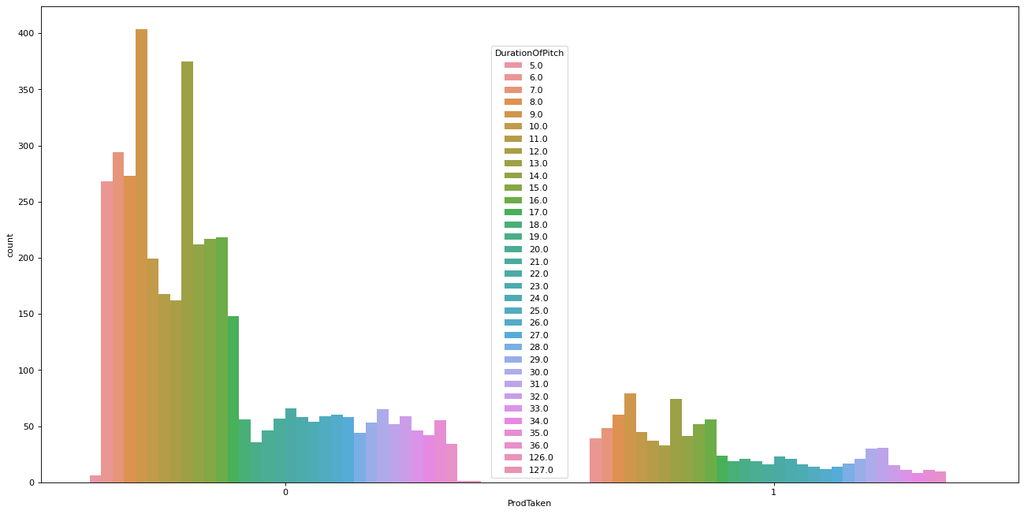

```python
# ProdTaken vs DurationOfPitch
print('ProdTaken by DurationOfPitch')
print('  ')
#print(tourismData.groupby('ProdTaken')['DurationOfPitch'].value_counts()/tourismData.shape[0]*100)
figure(figsize=(20,10), dpi=80)
sns.countplot(x=tourismData['ProdTaken'],hue=tourismData['DurationOfPitch']);
```

### Observations:

1. Out of all the people who bought the Travel Package, most of them heard the pitch for 9 mins.

```
Count of ProdTaken by Occupation

Occupation      ProdTaken
Free Lancer     1               2
Large Business  0             314
                1             120
Salaried        0            1950
                1             413
Small Business  0            1682
                1             382
Name: ProdTaken, dtype: int64
```

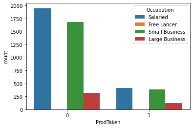

```python
# ProdTaken vs Occupation
print('Count of ProdTaken by Occupation')
print('  ')
print(tourismData.groupby('Occupation')['ProdTaken'].value_counts(ascending=False))
print('  ')

sns.countplot(x=tourismData['ProdTaken'],hue=tourismData['Occupation']);
```

### Observations:

1. There were only 2 free lancers who got the information on Travel Package, and both of them ended up buying the pakcage. Since there is not enough data for Free Lancers, we can't certainly comment on the conversion rate (product pitch --> sale conversion).
2. Out of all the customers who are Large Business who got information for the travel package, 27.6% ended up buying the travel package. This is the highest conversion rate in all the oocupation groups.
3. Out of all the customers who are Small Business who got information for the travel package, 18% ended up buying the travel package.
4. Out of all the customers who are Salaried who got information for the travel package, 17.4% ended up buying the travel package.

```
Count of ProdTaken by Gender

Gender  ProdTaken
Female  0            1620
        1             342
Male    0            2326
        1             575
Name: ProdTaken, dtype: int64

Percentage of ProdTaken by Gender

Gender  ProdTaken
Female  0            33.312770
        1             7.032696
Male    0            47.830557
        1            11.823977
Name: ProdTaken, dtype: float64
```

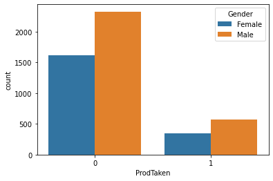

```python
# ProdTaken vs Gender
print('Count of ProdTaken by Gender')
print('  ')
print(tourismData.groupby('Gender')['ProdTaken'].value_counts(ascending=False))
print('  ')
print('Percentage of ProdTaken by Gender ')
print('  ')
print(tourismData.groupby('Gender')['ProdTaken'].value_counts()/tourismData.shape[0]*100)
sns.countplot(x=tourismData['ProdTaken'],hue=tourismData['Gender']);
```

### Observations:

1. The stats show that out of all the Females who get the Product information, only 17.4% ended up buying the Travel Package.
2. Out of all the Males, who got the Product Information, only 19.8% ended up buying the travel package.
3. From the Univariate analysis of Genders, it shows that most of the people who get the product information are males, so percentage of males buying the product more makes sense.

```
Count of ProdTaken by NumberOfPersonVisiting

NumberOfPersonVisiting  ProdTaken
1                       0              39
2                       0            1136
                        1             265
3                       0            1935
                        1             459
4                       0             833
                        1             193
5                       0               3
Name: ProdTaken, dtype: int64
```

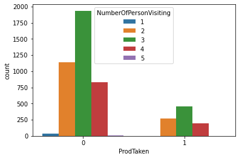

```python
# ProdTaken vs NumberOfPersonVisiting
print('Count of ProdTaken by NumberOfPersonVisiting')
print('  ')
print(tourismData.groupby('NumberOfPersonVisiting')['ProdTaken'].value_counts(ascending=False))
sns.countplot(x=tourismData['ProdTaken'],hue=tourismData['NumberOfPersonVisiting']);
```

### Observations:

1. Out of all the people who bought the Travel package, most of the people travel in group of 3.
2. Other stats represent that most of these groups are small families with a child.
3. The next popular number is 2 people traveling together, which might indicate that this is a couple, traveling together.

```
Count of ProdTaken by NumberOfFollowups

NumberOfFollowups  ProdTaken
1.0                0             152
                   1              20
2.0                0             205
                   1              24
3.0                0            1214
                   1             242
4.0                0            1720
                   1             386
5.0                0             573
                   1             191
6.0                0              82
                   1              54
Name: ProdTaken, dtype: int64
```

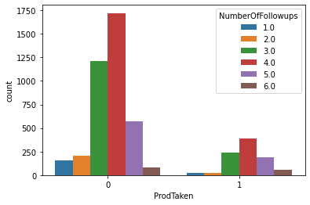

```python
# ProdTaken vs NumberOfFollowups
print('Count of ProdTaken by NumberOfFollowups')
print('  ')
print(tourismData.groupby('NumberOfFollowups')['ProdTaken'].value_counts(ascending=False))
sns.countplot(x=tourismData['ProdTaken'],hue=tourismData['NumberOfFollowups']);
```

### Observations:

```
Count of ProdTaken by ProductPitched

ProductPitched  ProdTaken
Basic           0            1283
                1             549
Deluxe          0            1513
                1             204
King            0             210
                1              20
Standard        0             618
                1             124
Super Deluxe    0             322
                1              20
Name: ProdTaken, dtype: int64
```

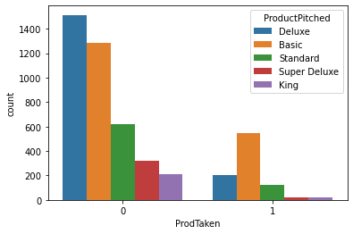

```python
# ProdTaken vs ProductPitched
print('Count of ProdTaken by ProductPitched')
print('  ')
print(tourismData.groupby('ProductPitched')['ProdTaken'].value_counts(ascending=False))
sns.countplot(x=tourismData['ProdTaken'],hue=tourismData['ProductPitched']);
```

### Observations:

1. Out of all the people who bought the Travel package:
   - 22.2% preferred Deluxe package.
   - 59.8% preferred Basic package.
   - 13.5% preferred Standard package.
   - 2.1% preferred Super Deluxe package.
   - 2.1% preferred King package.
2. Most of the people who bought the Travel Package prefer the Basic package.
3. Travel company can use this stat to focus more on the Basic package and look to create more varieties of Basic package like "Adventure-Basic", "R&R-Basic", "Spiritual Retreat- Basic" etc.

```
Count of ProdTaken by PreferredPropertyStar

PreferredPropertyStar  ProdTaken
3.0                    0            2514
                       1             486
4.0                    0             730
                       1             182
5.0                    0             702
                       1             249
Name: ProdTaken, dtype: int64
```

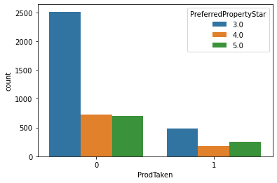

```python
# ProdTaken vs PreferredPropertyStar
print('Count of ProdTaken by PreferredPropertyStar')
print('  ')
print(tourismData.groupby('PreferredPropertyStar')['ProdTaken'].value_counts(ascending=False))
sns.countplot(x=tourismData['ProdTaken'],hue=tourismData['PreferredPropertyStar']);
```